# Predictive Analytics & Forecasting - Homework #3

Eric Kenney

2023-08-11

## Data Set

For this homework I will be using the Federal Reserve Economic Data (FRED) set on the effective federal interest rate. This includes daily data from July 1954 to August 2023. Additionally, I am using the CPI growth rate information from FRED as a predictor for the interest rate, since the Federal Reserve will raise rates as a way to curb inflation. The inflation data is complete from Mar 1967 on so I filter both sets of data to after that period.

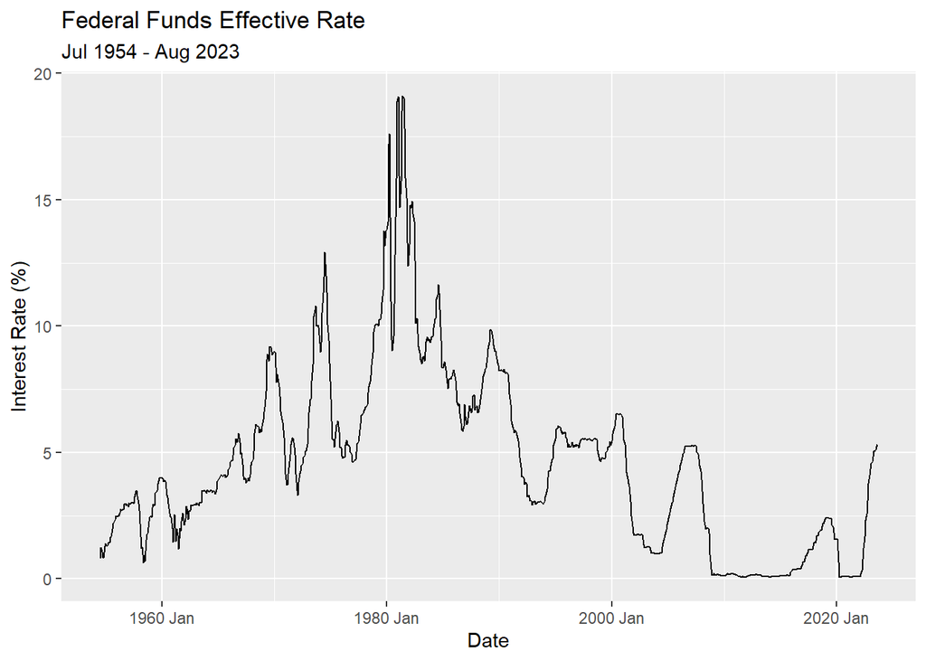

```r
# Read in data
interest_rate = read.csv(file.path(path, "federal_interest_rate.csv"))
inflation = read.csv(file.path(path, "inflation.csv"))

# Convert to monthly tsibble
## Interest Rate
interest_rate = interest_rate %>%
  rename("date" = "DATE", "interest" = "DFF") %>%
  mutate(date = yearmonth(date)) %>%
  group_by(date) %>%
  summarise(interest = mean(interest)) %>%
  as_tsibble(index = date)

## Inflation
inflation = inflation %>%
  rename("date" = "DATE", "CPI" = "CPALTT01USM657N") %>%
  mutate(date = yearmonth(date)) %>%
  as_tsibble(index = date)

# Plot
## Interest Rate
interest_rate %>%
  autoplot(interest) +
  labs(x = "Date", y = "Interest Rate (%)",
       title = "Federal Funds Effective Rate",
       subtitle = "Jul 1954 - Aug 2023")
```

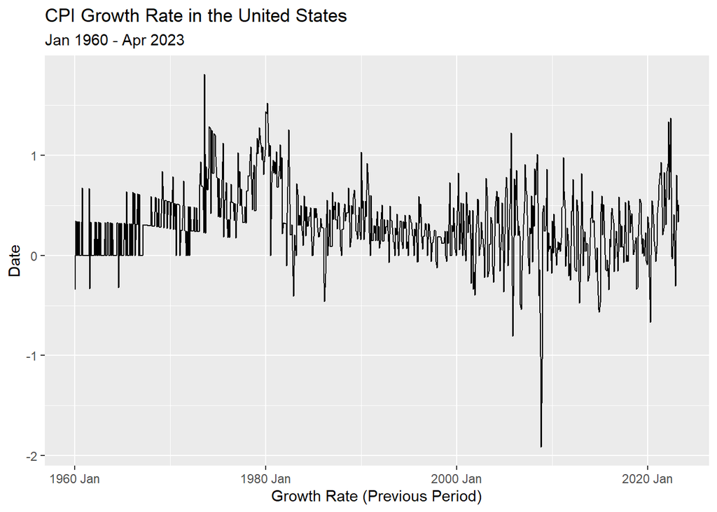

```r
## Inflation
inflation %>%
  autoplot(CPI) +
  labs(x = "Growth Rate (Previous Period)", y = "Date",
       title = "CPI Growth Rate in the United States",
       subtitle = "Jan 1960 - Apr 2023")
```

```r
# Filter down to complete data and join
interest_rate = interest_rate %>%
  filter(as.Date(date) >= "1967-03-01")

inflation = inflation %>%
  filter(as.Date(date) >= "1967-03-01")

interest_rate_data = left_join(interest_rate, inflation, by = "date")

# Create Lagged values for the predictor
interest_rate_data = interest_rate_data %>%
  mutate(CPI_lag = lag(CPI, 12)) %>%
  filter(!is.na(CPI_lag))
```

The full plot of the data shows a historical high of almost 20% during the recession in the 1980s. The last year (which I intend to forecast) is after a historic drop in rates due to the COVID-19 pandemic. I will reduce the data to end in December 2019 and use 2019 as the test set.

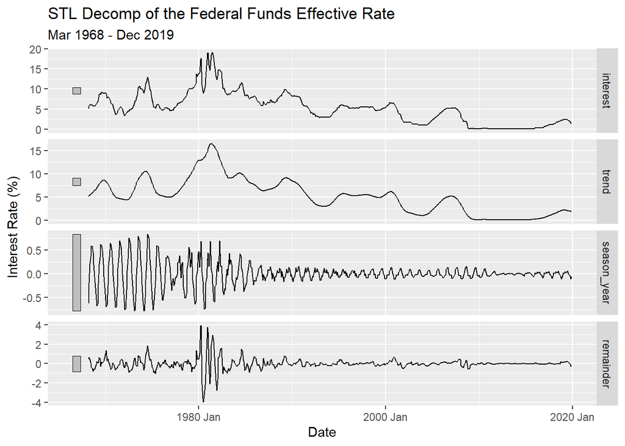

```r
# New Time Slice
interest_rate_data = interest_rate_data %>%
  filter(as.Date(date) <= "2019-12-01")

# STL Decomp of the data
interest_rate_data %>%
  model(STL(interest)) %>%
  components() %>%
  autoplot() +
  labs(x = "Date", y = "Interest Rate (%)",
       title = "STL Decomp of the Federal Funds Effective Rate",
       subtitle = "Mar 1968 - Dec 2019")
```

```r
# Create Training and Test Sets
total_obs = dim(interest_rate_data)[1]
test_obs = 12
train_obs = total_obs - test_obs

interest_rate_train = head(interest_rate_data, train_obs)
interest_rate_test = tail(interest_rate_data, test_obs)
```

This time slice works better than the most recent five years. The STL decomposition shows a fairly continuous trend with a drop the last year which may cause some issues with the forecasting. I will work with and model from this set.